[figure not shown]

# Apresentação

A Ciência de Dados é um conjunto de metodologias e tecnologias focadas na **criação de valor** para um negócio. Nosso approach é embasado na metodologia [BADIR](https://aryng.com/aryng_BADIR_advantage), que inicia com a questão de negócios, passando por coleta, tratamento e análise, e termina com a comunicação e utilização dos insights:

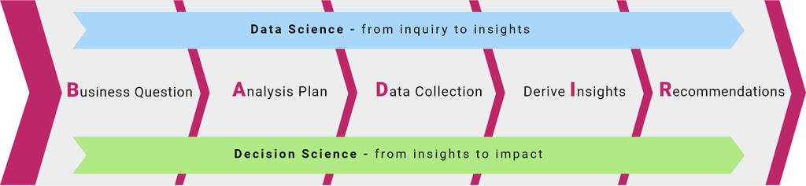

# Nossa empresa

Desde 2012, já atuamos em cerca de 20 projetos em Ciência de Dados no Brasil e exterior, tanto em R como Python. Focamos em identificação e validação de oportunidades e implantação de modelos preditivos e ferramentas de apoio à decisão (dashboards, live reports etc.). Também oferecemos cursos de Ciência de Dados para instituições de ensino e empresas.

# Equipe

Além de diretor [Dan S. Reznik](https://www.linkedin.com/in/dan-s-reznik-bb49133/) (PhD em Ciência da Computação pela UC-Berkeley), contamos com uma equipe de jovens cientistas de dados formados pelas melhores Universidades do país.

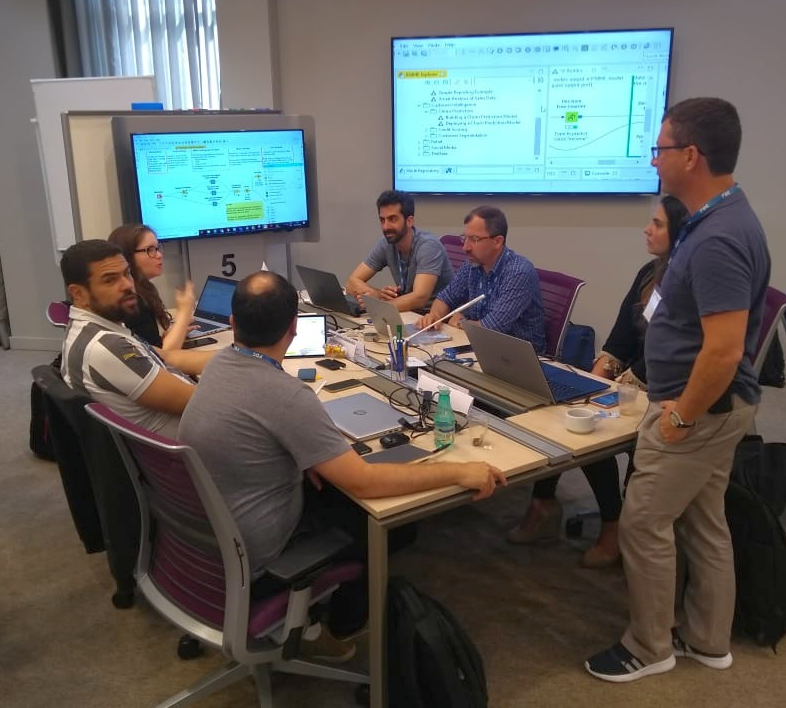

# Projetos

Atuamos tanto nas fases de planejamento estratégico quanto na execução, com equipe própria e/ou do cliente.

## Verticais e Clientes

- Setor Financeiro: Bradesco
- Consumer/Internet: Peixe Urbano, Gazeus Games
- Marketing Platforms: Bettrads, Fielo Loyalty
- Oil & Gas: Ouro Negro
- Healthcare: Amil UHG, Einstein, Fleury, Conexa Saúde.
- Governo: SEPLAG-MG, Secretaria de Educação-SP
- Startups: Instituto Igarapé, Loft, Loggi

[figure not shown]

## Produtos de Entrega

- Relatórios Analíticos
- Dashboards (Shiny e JS)
- Modelos preditivos (via API)

Alguns exemplos:

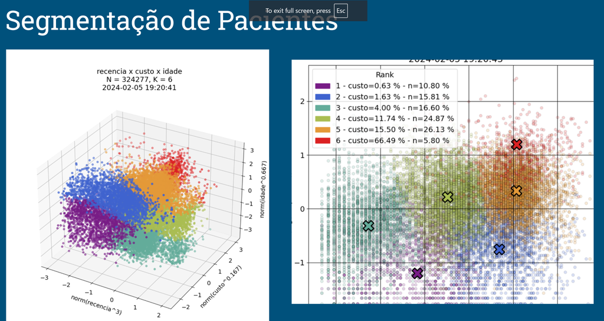

[figure not shown]

# Cursos de capacitação

Oferecemos cursos de capacitação de curta o média duração para empresas e instituições. Para mais informações, consultar cursos de Ciência de Dados.

# Contato

- Email: dreznik@gmail.com
- Linkedin: [dan-s-reznik-bb49133](https://www.linkedin.com/in/dan-s-reznik-bb49133/)
- Whatsapp: (21) 98574-7382

Atualização: May 2024.